Test Description in main

# About Polyglot Notebooks

Polyglot Notebooks is an extension, similar to Jupyter Notebooks where you can have files (notebooks) with cells of text and cells of code. In Polyglot Notebooks you can run bash/powershell, C#, and other code by clicking in the play button next to the cell.

You might need to ctrl + shif + p and restart the kernel for this notebook to run the code cells.

I will export the .ipynb file generated by the Polyglot Notebook into HTML but the ipynb file will be available as well.

Obs: You might need to uncomment some powershell commands by removing the # used to comment the line. The character (`) is used in powershell to break a long command into multiple lines.

# .NET compiling

## The traditional way of compiling and running C# code (JIT)

In simple terms .NET is a framework, AKA a set of standards that have to be followed. This framework gets source code from a programming language ,usually C# (.cs files in the case of C#), and generates intermediate code called Intermediate Language (IL) or Microsoft Intermediate Language (MSIL) code, this IL/MSIL code along with their metadata is packed into a assemblies, which is either a .dll or .exe files. .exe Files: Are generated for standalone applications (e.g., console applications, Windows Forms, WPF). .dll Files: Are Generated for class libraries and reusable components. You can change which file extension will be produced in the csproj file.

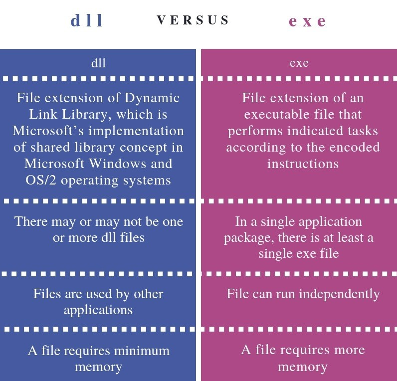

DLLs can be used by multiple EXEs:

[figure not shown]

The IL/MSIL code will be interpreted and compiled just in time (JIT) into machine code for a machine-specific architecture where the program will run. This way we code and compile the CLI once and can run in any platform, and different languages can generate the CLI.

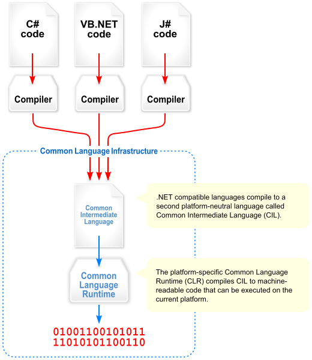

## The new way of compiling and running C# code (AOT)

Compiling code JIT has some advantages like runtime optimizations, like when part of the code is often called during runtime (AKA a hotspot) the compiler can optimize to load that code section, which cannot be done in the Ahead of Time (AOT) Compilation process.

There is a trade-off because AOT code usually use less memory, has a faster startup, and has overall faster execution. You can use technologies like .NET Native and CoreRT to compile into Native code.

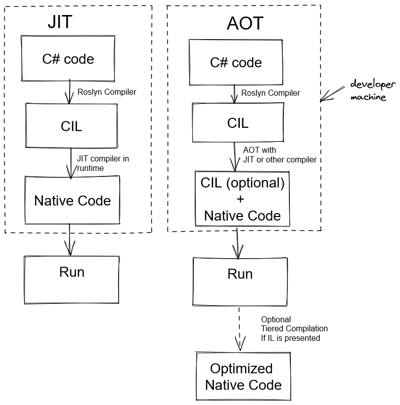

### AOT Self-contained

As we talked in the traditional approach the C# source code (.cs file) is compiled into IL/MSIL code that is contained into assemblies (.exe or .dll files). The assemblies are compiled Just In Time (JIT) into machine code for the specific architecture of the machine that will run the program. To run the IL/MSIL code the machine has to have the .NET Common Language Runtime (CLR) installed (Behaves a lot like JVM). Like this:

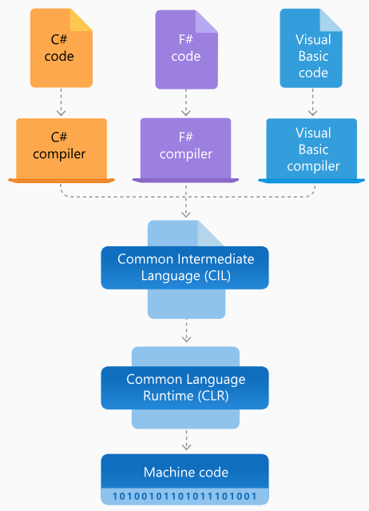

The SDK (Software Development Kit) version of .NET contains everything contained in the CLR plus some features like debugging features that a person that would only run the program would not need.

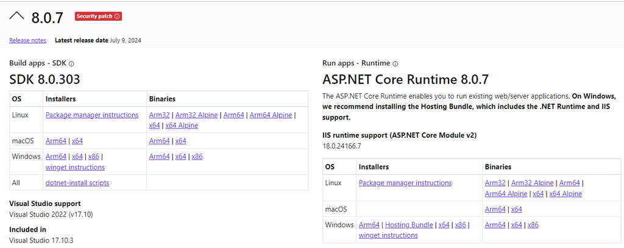

The CLR also contain some libraries that are often used in the code like basic IO. **We can compile C# code AOT in a self-contained unit, where the libraries from CLR are included in the compiled file. This will make the size of the file bigger since it will have the CLR libraries code, but it will make possible to run the code even in machines where the CLR is not installed. The code in the self-contained compiling process is plataform specific, once produced for an OS and architecture it can run on that platform only.**

### AOT Platform-specific and framework-dependent

You can compile your code AOT for a specific platform but require the machine that has the CLR installed.

# .NET, .NET CORE, and .NET Framework

All are versions of the same framework, a set of rules to be followed and tools, that allow the developer and the user to create, compile and run code form a .NET compatible language (usually C#) into IL/MSIL and in the end into machine code. **.NET framework is an old version of .NET that uses DLLs from the Windows Operational System, this made this version of .NET platform dependent, running only in windows machines.** A new version of .NET was created that would **NOT** rely on Windows, it is named .NET CORE. After version 5 of .NET the term .NET is now refering to .NET CORE.

```python
#Comments in PowerShell start with #.
#Check which version of .NET SDK you have installed (needed to develop, debug, compile, usually what devs want)
dotnet --list-sdks
```

```
6.0.321 [C:\Program Files\dotnet\sdk]
7.0.102 [C:\Program Files\dotnet\sdk]
8.0.107 [C:\Program Files\dotnet\sdk]
```

```python
#Check which version of .NET RUNTIME you have installed (version used only to run the IL/MSIL code)
dotnet --list-runtimes
```

[output not shown]

```python
#Check everything together
dotnet sdk check
```

```
.NET SDKs:
Version      Status
---------------------------------------------------
6.0.321      .NET 6.0 is going out of support soon.
7.0.102      .NET 7.0 is out of support.
8.0.107      Up to date.

Try out the newest .NET SDK features with .NET 9.0.100-preview.6.24328.19.

.NET Runtimes:
Name                              Version      Status
-------------------------------------------------------------------------------------
Microsoft.AspNetCore.All          2.1.30       .NET 2.1 is out of support.
Microsoft.AspNetCore.App          2.1.30       .NET 2.1 is out of support.
Microsoft.NETCore.App             2.1.30       .NET 2.1 is out of support.
Microsoft.AspNetCore.App          6.0.13       .NET 6.0 is going out of support soon.
Microsoft.NETCore.App             6.0.13       .NET 6.0 is going out of support soon.
Microsoft.WindowsDesktop.App      6.0.13       .NET 6.0 is going out of support soon.
Microsoft.AspNetCore.App          6.0.26       .NET 6.0 is going out of support soon.
Microsoft.NETCore.App             6.0.26       .NET 6.0 is going out of support soon.
Microsoft.WindowsDesktop.App      6.0.26       .NET 6.0 is going out of support soon.
Microsoft.AspNetCore.App          7.0.2        .NET 7.0 is out of support.
Microsoft.NETCore.App             7.0.2        .NET 7.0 is out of support.
Microsoft.WindowsDesktop.App      7.0.2        .NET 7.0 is out of support.
Microsoft.AspNetCore.App          8.0.7        Up to date.
Microsoft.NETCore.App             8.0.7        Up to date.
Microsoft.WindowsDesktop.App      8.0.7        Up to date.


The latest versions of .NET can be installed from https://aka.ms/dotnet-core-download. For more information about .NET lifecycles, see https://aka.ms/dotnet-core-support.
```

# DOTNET CLI

DOTNET Command Line Interface (CLI) is a tool where you can run dotnet commands that comes within the SDK.

## COMMANDS STRUCTURE

To run DOTNET CLI commands run dotnet, command, and possibly command arguments and options.

### DO YOU NEED TO LEARN DOTNET COMMANDS?

To be honest a lot of IDE's will run dotnet commands under the hood for you and you might never have used a command, like building a project by simply clicking in one button. Despite that, I believe knowing some commands might give you a better understanding of the whole development process and you might face a situation where you have to run commands in a no GUI environment like a CI/CD pipeline or running your server on the cloud. I would recommend trying to run the commands before going to the IDE.

### -h --help

You can run -h or --help after a command to get more information about it, or cheching the documentation on Microsoft's website.

# DOTNET NEW

You can open any text editor like notepad, white some code, save it with .cs extension and have your C# code ready to run, but this is not very efficient. We usually rely on templates with some boilerplate and pre-set already created for us.

## DOTNET NEW STRUCTURE

**dotnet new [TEMPLATE] [OPTIONS]**

You can create your own templates, install third party templates, and search for other templates. We will use the default ones from Microsoft only for now.

### DOTNET NEW CONSOLE

Console is a basic aplication that will open an instance of your machine console terminal, it will often close when the terminal is closed and it will often be interacted by the user using inputs in the console.

### OPTIONS AND ARGUMENTS

WE WILL USE **SOME OF OPTIONS** THAT ARE OFTEN NOT USED ONLY TO SHOWCASE THEM. Most are optional, check -h to know more.

- --dry-run : Adding this will "pretend" to run the command and tell you what would be the outcome if it ran without the command, tells if error or success woudl happen as well.
- -n : Give a name for the output
- -o : Give output folder for creation
- --force : Forces the creation, even if it would change existing files
- --no-update-check : Disable checking for templates when instantiating a template
- --project : If you have a project file .csproj file you could link your code to it
- -lang : The programming language used
- --framework : The framework used
- --no-restore : Defines if skip or not the automatic restore on create
- --use-program-main : if you want to use the main method entrypoint or a top-level statement
- --aot : to allow the use of AOT when publishing the program

```python
# To get some help information use -h or --help like this
#dotnet new -h

# To get a list of the templates you can run this command
# dotnet new templates
```

```python
# DOTNET NEW CONSOLE
#dotnet new console -h

#WE WILL USE SOME OPTIONS THAT ARE OFTEN NOT USED ONLY TO SHOWCASE THEM:

dotnet new console -n myNameInArgName -o consoleAppFolder --force -lang 'C#' `
--use-program-main true --framework 'net8.0' --no-update-check --no-restore true `
#--dry-run
```

```
The template "Console App" was created successfully.
```

### DOTNET NEW CONSOLE OUTCOME FILES

You might see that the folder was created and the following files were created inside this folder:

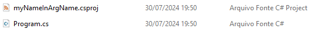

There are 2 extensions, .cs and .csproj. We will talk more about them:

#### **.cs (C# source files)**

- **Program.cs file:**

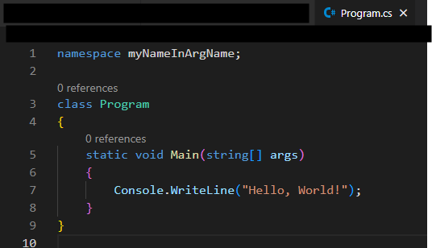

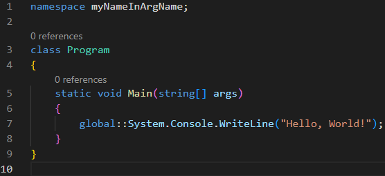

  - Or you can remove the ; after the name of your namespace and include a block after. Now you can include everything you want to declare inside the namespace within that block {}.

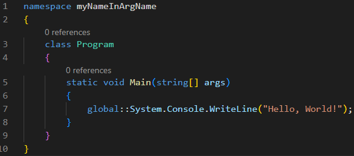

- **Referencing namespaces**: We include on top of the file the keyword using followed by the namespace we want to enable to be refenced by that file. It is possible to make a namespace globally available to the whole project, we include global keyword before the using keyword, it is recommended to certer your global usings either in a empty .cs file in the root or in your entrypoint file. You can have using static namespace to make it easier to reference static members of the namespace but it can get confusing, like this:

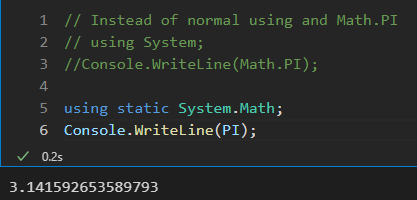

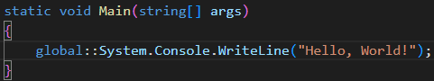

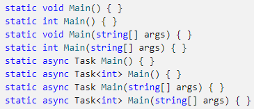

- **"Modern" aplication entry point (top-level statements)**: Inside our Main method we would have the begining of our code. Now we have something called Top-level statement that aims to reduce the boilerplate code and make C# more "modern". It is a file without classes and that is not contained explicitly in a code block. It is basically removing everything other than what you would keep inside the codeblock of a Main method and it will behave like the body of the Main method, like this:

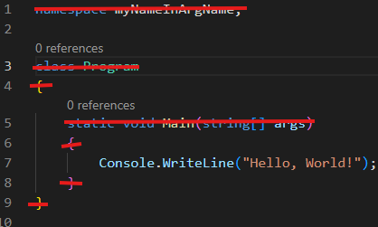

- **Default entry point file naming**: You can name the file with the entrypoint anything, as long as it has an implementation of the Main method or it uses the top-level statement, but by convention we name it **Program.cs**.
- **More about entry points**:
  - Using top level statements is compiled as if it’s inside an anonymous static class generated by the compiler, and therefore you cannot access things from this anonymous class.
  - You can't declare methods inside your top-level statement, but you can declare a class or even a namespace and inside it you can declare a method.
  - If part of your code in the top-level statement is not explicitly in a namespace it will be inside the global namespace.
  - Top level statements is the new default, if you remove the option "--use-program-main true" when we created the console app via CLI or set it as false you would create a top-level statement file.
  - You can only have one Main method or only one file with top level statements, otherwise you will get an error(you can work around it but it is not a good practice).

### DOTNET NEW SLN

SLN, short for solution, is a file used to manage different projects in a single environment. It allows some integrated development environments (IDEs) and text editors to display all projects and their files for that solution. It also help manage dependencies between projects and the compile order (one project might reference code from another project, therefore the one referenced has to be compiled first). It also can define build configurations.

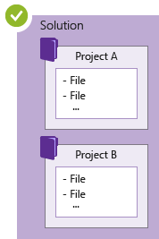

### DO I NEED TO GO IN DEPTH ABOUT .SLN FILES?

**PROBABLY NOT**. You will probabbly edit way more a csproj file to edit your projects individually than editing a solution file. Usually we interact with the solution file via IDE or via CLI only.

### THE NEW SOLUTION FILE .SLNX

The .slnx file serves the same purpose than the .sln file but it uses XML and is more concise.

### WHY SHOULD I USE MULTIPLE PROJECTS?

You saw that by default when we create the simplest template app possible, a console application, a project file (.csproj) is automatically created as well. This happens because we almost always want C# files to be referenced and centralized in a .csproj file.

**Why can't I have all my code in a single project?**

- **Separation of Concerns**: Each project can represent a distinct component or **layer of the application**, such as data access, business logic, and presentation. We also get more modularity, where there is boundary between different components.
- **Reusability and Encapsulation**: A project can be used by different projects. We can create a web scraping (AKA extracting information from websites) project for instance and pack it as library (DLL) that can be used by any other project that might use this web scraping functionality. You can also encapsulate part of the library making available only resources you want and hidding internal implementations.
- **Build performance**: You can build only projects that changed and you can build different projects in parallel.
- **Team Collaboration**: Since projects are compiled into different units you can work with isolated projects without interfering with other projects someone else could be working on.
- **Testing and Deployment**: You can build test files to separated projects. You can also deploy one project in a powerful cloud computer because it needs a lot of computational power and keep less demanding parts of the system in another project deployed in a week machine.
- **Dependency Management and Versioning**: Since projects explicitly state their dependencies it is easier to manage the relationship between different parts of the application. You will have more flexibility about versioning, allowing you to version different parts (projects) within your system.
- **Standards**: Some organizations require this standard (separation into different projects) to be followed for the reasons above.

### OPTIONS AND ARGUMENTS

WE WILL USE **SOME OF OPTIONS** THAT ARE OFTEN NOT USED ONLY TO SHOWCASE THEM. Most are optional, check -h to know more.

- --dry-run : Adding this will "pretend" to run the command and tell you what would be the outcome if it ran without the command, tells if error or success woudl happen as well.